# A mini project : Feature and Model Selection

1. Imports Introduction
2. Overview of the dataset
3. Data splitting
4. EDA
5. Preprocessing and transformations
6. Baseline model
7. Linear models
8. Different models
9. Hyperparameter optimization
10. Interpretation and feature importances
11. Results on the test set
12. Summary of the results

## Imports

```python
import os

import matplotlib.pyplot as plt
import numpy as np
import pandas as pd

from sklearn import datasets
from sklearn.compose import ColumnTransformer, make_column_transformer
from sklearn.dummy import DummyRegressor, DummyClassifier
from sklearn.linear_model import LogisticRegression, Ridge
from sklearn.feature_extraction.text import CountVectorizer
from sklearn.impute import SimpleImputer
from sklearn.metrics import (
    accuracy_score,
    auc,
    average_precision_score,
    classification_report,
    confusion_matrix,
    f1_score,
    make_scorer,
    precision_score,
    recall_score,
)

from sklearn.model_selection import (
    cross_val_score,
    cross_validate,
    train_test_split,
)

from sklearn.pipeline import Pipeline, make_pipeline
from sklearn.preprocessing import OneHotEncoder, OrdinalEncoder, StandardScaler
from sklearn.tree import DecisionTreeRegressor, export_graphviz

%matplotlib inline
```

## Introduction

This is a mini-project where my group consolidated all the various concepts we learned in the Supervised Learning and Model Selection course during the Master's Program at UBC to address an interesting problem.

## Problem:

- A classification problem of predicting whether a credit card client will default or not. For this problem, you will use [Default of Credit Card Clients Dataset](https://www.kaggle.com/uciml/default-of-credit-card-clients-dataset). In this data set, there are 30,000 examples and 24 features, and the goal is to estimate whether a person will default (fail to pay) their credit card bills; this column is labeled "default.payment.next.month" in the data.

## 1. Overview of the dataset

- The data set is about credit transactions of credit card clients in Taiwan from April 2005 to September 2005.
- The problem is to predict whether a credit card client will default (fail to pay) the credit card bills.
- The target column is `default.payment.next.month` with 2 values: 1 = yes, 0 = no.
- The following 23 features can be used as explanatory variables:
  - LIMIT_BAL: Amount of the given credit (NT dollar)
  - SEX: Gender (1 = male, 2 = female)
  - EDUCATION: Education level (1 = graduate school, 2 = university, 3 = high school, 4 = others, 5 or 6 = unknown)
  - MARRIAGE: Marital status (1 = married, 2 = single, 3 = others)
  - AGE: Age (years)
  - PAY_0 – PAY_6: Status of past monthly payment (-1 = pay duly, 1 = payment delay for one month,..., 9 = payment delay for nine months and above), where PAY_0 = repayment status in September 2005,..., PAY_6 = repayment status in April 2005.
  - BILL_AMT1 – BILL_AMT6: Amount of bill statement (NT dollar) from September 2005 to April 2005, respectively.
  - PAY_AMT1 – PAY_AMT6: Amount of previous statement (NT dollar) from September 2005 to April 2005, respectively.

```python
# 2. Read in the data
credit_card_df = pd.read_csv("UCI_Credit_Card.csv")
credit_card_df.sort_index()
```

|  | ID | LIMIT_BAL | SEX | EDUCATION | MARRIAGE | AGE | PAY_0 | PAY_2 | PAY_3 | PAY_4 | ... | BILL_AMT4 | BILL_AMT5 | BILL_AMT6 | PAY_AMT1 | PAY_AMT2 | PAY_AMT3 | PAY_AMT4 | PAY_AMT5 | PAY_AMT6 | default.payment.next.month |
| --- | --- | --- | --- | --- | --- | --- | --- | --- | --- | --- | --- | --- | --- | --- | --- | --- | --- | --- | --- | --- | --- |
| 0 | 1 | 20000.0 | 2 | 2 | 1 | 24 | 2 | 2 | -1 | -1 | ... | 0.0 | 0.0 | 0.0 | 0.0 | 689.0 | 0.0 | 0.0 | 0.0 | 0.0 | 1 |
| 1 | 2 | 120000.0 | 2 | 2 | 2 | 26 | -1 | 2 | 0 | 0 | ... | 3272.0 | 3455.0 | 3261.0 | 0.0 | 1000.0 | 1000.0 | 1000.0 | 0.0 | 2000.0 | 1 |
| 2 | 3 | 90000.0 | 2 | 2 | 2 | 34 | 0 | 0 | 0 | 0 | ... | 14331.0 | 14948.0 | 15549.0 | 1518.0 | 1500.0 | 1000.0 | 1000.0 | 1000.0 | 5000.0 | 0 |
| 3 | 4 | 50000.0 | 2 | 2 | 1 | 37 | 0 | 0 | 0 | 0 | ... | 28314.0 | 28959.0 | 29547.0 | 2000.0 | 2019.0 | 1200.0 | 1100.0 | 1069.0 | 1000.0 | 0 |
| 4 | 5 | 50000.0 | 1 | 2 | 1 | 57 | -1 | 0 | -1 | 0 | ... | 20940.0 | 19146.0 | 19131.0 | 2000.0 | 36681.0 | 10000.0 | 9000.0 | 689.0 | 679.0 | 0 |
| ... | ... | ... | ... | ... | ... | ... | ... | ... | ... | ... | ... | ... | ... | ... | ... | ... | ... | ... | ... | ... | ... |
| 29995 | 29996 | 220000.0 | 1 | 3 | 1 | 39 | 0 | 0 | 0 | 0 | ... | 88004.0 | 31237.0 | 15980.0 | 8500.0 | 20000.0 | 5003.0 | 3047.0 | 5000.0 | 1000.0 | 0 |
| 29996 | 29997 | 150000.0 | 1 | 3 | 2 | 43 | -1 | -1 | -1 | -1 | ... | 8979.0 | 5190.0 | 0.0 | 1837.0 | 3526.0 | 8998.0 | 129.0 | 0.0 | 0.0 | 0 |
| 29997 | 29998 | 30000.0 | 1 | 2 | 2 | 37 | 4 | 3 | 2 | -1 | ... | 20878.0 | 20582.0 | 19357.0 | 0.0 | 0.0 | 22000.0 | 4200.0 | 2000.0 | 3100.0 | 1 |
| 29998 | 29999 | 80000.0 | 1 | 3 | 1 | 41 | 1 | -1 | 0 | 0 | ... | 52774.0 | 11855.0 | 48944.0 | 85900.0 | 3409.0 | 1178.0 | 1926.0 | 52964.0 | 1804.0 | 1 |
| 29999 | 30000 | 50000.0 | 1 | 2 | 1 | 46 | 0 | 0 | 0 | 0 | ... | 36535.0 | 32428.0 | 15313.0 | 2078.0 | 1800.0 | 1430.0 | 1000.0 | 1000.0 | 1000.0 | 1 |

30000 rows × 25 columns

**Preliminary Preprocessing**:\ Based on the results of `.info()` and `.describe()` below, we can see that there are no missing values in the data set, and feature names are quite standard except that the repayment status columns are `PAY_0`, `PAY_2`, etc. with no `PAY_1`). Hence, besides renaming column `PAY_0` to `PAY_1`, there is no need to do any other preliminary preprocessing.

```python
credit_card_df.info()
```

```
<class 'pandas.core.frame.DataFrame'>
RangeIndex: 30000 entries, 0 to 29999
Data columns (total 25 columns):
 #   Column                      Non-Null Count  Dtype
---  ------                      --------------  -----
 0   ID                          30000 non-null  int64
 1   LIMIT_BAL                   30000 non-null  float64
 2   SEX                         30000 non-null  int64
 3   EDUCATION                   30000 non-null  int64
 4   MARRIAGE                    30000 non-null  int64
 5   AGE                         30000 non-null  int64
 6   PAY_0                       30000 non-null  int64
 7   PAY_2                       30000 non-null  int64
 8   PAY_3                       30000 non-null  int64
 9   PAY_4                       30000 non-null  int64
```

[output cut: 17 more lines]

```python
credit_card_df.describe().T
```

|  | count | mean | std | min | 25% | 50% | 75% | max |
| --- | --- | --- | --- | --- | --- | --- | --- | --- |
| ID | 30000.0 | 15000.500000 | 8660.398374 | 1.0 | 7500.75 | 15000.5 | 22500.25 | 30000.0 |
| LIMIT_BAL | 30000.0 | 167484.322667 | 129747.661567 | 10000.0 | 50000.00 | 140000.0 | 240000.00 | 1000000.0 |
| SEX | 30000.0 | 1.603733 | 0.489129 | 1.0 | 1.00 | 2.0 | 2.00 | 2.0 |
| EDUCATION | 30000.0 | 1.853133 | 0.790349 | 0.0 | 1.00 | 2.0 | 2.00 | 6.0 |
| MARRIAGE | 30000.0 | 1.551867 | 0.521970 | 0.0 | 1.00 | 2.0 | 2.00 | 3.0 |
| AGE | 30000.0 | 35.485500 | 9.217904 | 21.0 | 28.00 | 34.0 | 41.00 | 79.0 |
| PAY_0 | 30000.0 | -0.016700 | 1.123802 | -2.0 | -1.00 | 0.0 | 0.00 | 8.0 |
| PAY_2 | 30000.0 | -0.133767 | 1.197186 | -2.0 | -1.00 | 0.0 | 0.00 | 8.0 |
| PAY_3 | 30000.0 | -0.166200 | 1.196868 | -2.0 | -1.00 | 0.0 | 0.00 | 8.0 |
| PAY_4 | 30000.0 | -0.220667 | 1.169139 | -2.0 | -1.00 | 0.0 | 0.00 | 8.0 |
| PAY_5 | 30000.0 | -0.266200 | 1.133187 | -2.0 | -1.00 | 0.0 | 0.00 | 8.0 |
| PAY_6 | 30000.0 | -0.291100 | 1.149988 | -2.0 | -1.00 | 0.0 | 0.00 | 8.0 |
| BILL_AMT1 | 30000.0 | 51223.330900 | 73635.860576 | -165580.0 | 3558.75 | 22381.5 | 67091.00 | 964511.0 |
| BILL_AMT2 | 30000.0 | 49179.075167 | 71173.768783 | -69777.0 | 2984.75 | 21200.0 | 64006.25 | 983931.0 |
| BILL_AMT3 | 30000.0 | 47013.154800 | 69349.387427 | -157264.0 | 2666.25 | 20088.5 | 60164.75 | 1664089.0 |
| BILL_AMT4 | 30000.0 | 43262.948967 | 64332.856134 | -170000.0 | 2326.75 | 19052.0 | 54506.00 | 891586.0 |
| BILL_AMT5 | 30000.0 | 40311.400967 | 60797.155770 | -81334.0 | 1763.00 | 18104.5 | 50190.50 | 927171.0 |
| BILL_AMT6 | 30000.0 | 38871.760400 | 59554.107537 | -339603.0 | 1256.00 | 17071.0 | 49198.25 | 961664.0 |
| PAY_AMT1 | 30000.0 | 5663.580500 | 16563.280354 | 0.0 | 1000.00 | 2100.0 | 5006.00 | 873552.0 |
| PAY_AMT2 | 30000.0 | 5921.163500 | 23040.870402 | 0.0 | 833.00 | 2009.0 | 5000.00 | 1684259.0 |
| PAY_AMT3 | 30000.0 | 5225.681500 | 17606.961470 | 0.0 | 390.00 | 1800.0 | 4505.00 | 896040.0 |
| PAY_AMT4 | 30000.0 | 4826.076867 | 15666.159744 | 0.0 | 296.00 | 1500.0 | 4013.25 | 621000.0 |
| PAY_AMT5 | 30000.0 | 4799.387633 | 15278.305679 | 0.0 | 252.50 | 1500.0 | 4031.50 | 426529.0 |
| PAY_AMT6 | 30000.0 | 5215.502567 | 17777.465775 | 0.0 | 117.75 | 1500.0 | 4000.00 | 528666.0 |
| default.payment.next.month | 30000.0 | 0.221200 | 0.415062 | 0.0 | 0.00 | 0.0 | 0.00 | 1.0 |

```python
credit_card_df = credit_card_df.rename(columns={"PAY_0": "PAY_1"})
credit_card_df.sort_index()
```

|  | ID | LIMIT_BAL | SEX | EDUCATION | MARRIAGE | AGE | PAY_1 | PAY_2 | PAY_3 | PAY_4 | ... | BILL_AMT4 | BILL_AMT5 | BILL_AMT6 | PAY_AMT1 | PAY_AMT2 | PAY_AMT3 | PAY_AMT4 | PAY_AMT5 | PAY_AMT6 | default.payment.next.month |
| --- | --- | --- | --- | --- | --- | --- | --- | --- | --- | --- | --- | --- | --- | --- | --- | --- | --- | --- | --- | --- | --- |
| 0 | 1 | 20000.0 | 2 | 2 | 1 | 24 | 2 | 2 | -1 | -1 | ... | 0.0 | 0.0 | 0.0 | 0.0 | 689.0 | 0.0 | 0.0 | 0.0 | 0.0 | 1 |
| 1 | 2 | 120000.0 | 2 | 2 | 2 | 26 | -1 | 2 | 0 | 0 | ... | 3272.0 | 3455.0 | 3261.0 | 0.0 | 1000.0 | 1000.0 | 1000.0 | 0.0 | 2000.0 | 1 |
| 2 | 3 | 90000.0 | 2 | 2 | 2 | 34 | 0 | 0 | 0 | 0 | ... | 14331.0 | 14948.0 | 15549.0 | 1518.0 | 1500.0 | 1000.0 | 1000.0 | 1000.0 | 5000.0 | 0 |
| 3 | 4 | 50000.0 | 2 | 2 | 1 | 37 | 0 | 0 | 0 | 0 | ... | 28314.0 | 28959.0 | 29547.0 | 2000.0 | 2019.0 | 1200.0 | 1100.0 | 1069.0 | 1000.0 | 0 |
| 4 | 5 | 50000.0 | 1 | 2 | 1 | 57 | -1 | 0 | -1 | 0 | ... | 20940.0 | 19146.0 | 19131.0 | 2000.0 | 36681.0 | 10000.0 | 9000.0 | 689.0 | 679.0 | 0 |
| ... | ... | ... | ... | ... | ... | ... | ... | ... | ... | ... | ... | ... | ... | ... | ... | ... | ... | ... | ... | ... | ... |
| 29995 | 29996 | 220000.0 | 1 | 3 | 1 | 39 | 0 | 0 | 0 | 0 | ... | 88004.0 | 31237.0 | 15980.0 | 8500.0 | 20000.0 | 5003.0 | 3047.0 | 5000.0 | 1000.0 | 0 |
| 29996 | 29997 | 150000.0 | 1 | 3 | 2 | 43 | -1 | -1 | -1 | -1 | ... | 8979.0 | 5190.0 | 0.0 | 1837.0 | 3526.0 | 8998.0 | 129.0 | 0.0 | 0.0 | 0 |
| 29997 | 29998 | 30000.0 | 1 | 2 | 2 | 37 | 4 | 3 | 2 | -1 | ... | 20878.0 | 20582.0 | 19357.0 | 0.0 | 0.0 | 22000.0 | 4200.0 | 2000.0 | 3100.0 | 1 |
| 29998 | 29999 | 80000.0 | 1 | 3 | 1 | 41 | 1 | -1 | 0 | 0 | ... | 52774.0 | 11855.0 | 48944.0 | 85900.0 | 3409.0 | 1178.0 | 1926.0 | 52964.0 | 1804.0 | 1 |
| 29999 | 30000 | 50000.0 | 1 | 2 | 1 | 46 | 0 | 0 | 0 | 0 | ... | 36535.0 | 32428.0 | 15313.0 | 2078.0 | 1800.0 | 1430.0 | 1000.0 | 1000.0 | 1000.0 | 1 |

30000 rows × 25 columns

## 2. Data splitting

Split the data into train and test portions.\ `test_size` determines the portion of the data which will go into test sets.\ `random_state`: the purpose of setting a random seed (using random_state) is to ensure reproducibility

**Answer:**

```python
train_df, test_df = train_test_split(credit_card_df, test_size=0.3, random_state=123)
```

```python
train_df.head()
```

|  | ID | LIMIT_BAL | SEX | EDUCATION | MARRIAGE | AGE | PAY_1 | PAY_2 | PAY_3 | PAY_4 | ... | BILL_AMT4 | BILL_AMT5 | BILL_AMT6 | PAY_AMT1 | PAY_AMT2 | PAY_AMT3 | PAY_AMT4 | PAY_AMT5 | PAY_AMT6 | default.payment.next.month |
| --- | --- | --- | --- | --- | --- | --- | --- | --- | --- | --- | --- | --- | --- | --- | --- | --- | --- | --- | --- | --- | --- |
| 16395 | 16396 | 320000.0 | 2 | 1 | 2 | 36 | 0 | 0 | 0 | 0 | ... | 19370.0 | 10155.0 | 3788.0 | 5000.0 | 5018.0 | 1000.0 | 3000.0 | 0.0 | 7013.0 | 0 |
| 21448 | 21449 | 440000.0 | 2 | 1 | 2 | 30 | -1 | -1 | -1 | 0 | ... | 171244.0 | 150897.0 | 117870.0 | 612.0 | 87426.0 | 130007.0 | 3018.0 | 15000.0 | 51663.0 | 0 |
| 20034 | 20035 | 160000.0 | 2 | 3 | 1 | 44 | -2 | -2 | -2 | -2 | ... | -18.0 | -18.0 | -18.0 | 0.0 | 0.0 | 0.0 | 0.0 | 0.0 | 0.0 | 0 |
| 25755 | 25756 | 120000.0 | 2 | 2 | 1 | 30 | 0 | 0 | 0 | 0 | ... | 103058.0 | 71095.0 | 47379.0 | 3706.0 | 5502.0 | 4204.0 | 3017.0 | 2005.0 | 1702.0 | 0 |
| 1438 | 1439 | 50000.0 | 1 | 2 | 2 | 54 | 1 | 2 | 0 | 0 | ... | 27585.0 | 27910.0 | 27380.0 | 0.0 | 1400.0 | 1200.0 | 1500.0 | 1000.0 | 1500.0 | 0 |

5 rows × 25 columns

```python
train_df.shape
```

```
(21000, 25)
```

```python
X_train, y_train = train_df.drop(columns=["default.payment.next.month"]), train_df["default.payment.next.month"]
X_test, y_test = test_df.drop(columns=["default.payment.next.month"]), test_df["default.payment.next.month"]
```

## 3. Exploratory Data Analysis

The analysis is performed on the train set including two summary statistics and two visualizations to summarize our observations about the data. Then, appropriate metric(s) will be picked for further assessment.

**Summary Statistics & Visualization 1: Correlation among features**

```python
cor_all = train_df.corr()
cor_all
```

|  | ID | LIMIT_BAL | SEX | EDUCATION | MARRIAGE | AGE | PAY_1 | PAY_2 | PAY_3 | PAY_4 | ... | BILL_AMT4 | BILL_AMT5 | BILL_AMT6 | PAY_AMT1 | PAY_AMT2 | PAY_AMT3 | PAY_AMT4 | PAY_AMT5 | PAY_AMT6 | default.payment.next.month |
| --- | --- | --- | --- | --- | --- | --- | --- | --- | --- | --- | --- | --- | --- | --- | --- | --- | --- | --- | --- | --- | --- |
| ID | 1.000000 | 0.028419 | 0.019014 | 0.040633 | -0.024071 | 0.021795 | -0.029574 | -0.011899 | -0.017471 | -0.000293 | ... | 0.042005 | 0.020323 | 0.019477 | 0.013488 | 0.013389 | 0.036544 | 0.010153 | -0.000093 | 0.001252 | -0.017861 |
| LIMIT_BAL | 0.028419 | 1.000000 | 0.027466 | -0.223207 | -0.115202 | 0.146419 | -0.271686 | -0.299924 | -0.289222 | -0.269399 | ... | 0.297468 | 0.299353 | 0.293757 | 0.191669 | 0.183705 | 0.206416 | 0.204308 | 0.215244 | 0.215337 | -0.149247 |
| SEX | 0.019014 | 0.027466 | 1.000000 | 0.012307 | -0.033413 | -0.091890 | -0.061038 | -0.073214 | -0.068192 | -0.063772 | ... | -0.022471 | -0.015973 | -0.015158 | 0.001324 | 0.000908 | -0.008136 | 0.001473 | -0.004470 | -0.001600 | -0.046320 |
| EDUCATION | 0.040633 | -0.223207 | 0.012307 | 1.000000 | -0.142499 | 0.175042 | 0.111222 | 0.125907 | 0.118096 | 0.110732 | ... | 0.003286 | -0.005203 | -0.005595 | -0.039769 | -0.028295 | -0.039621 | -0.038918 | -0.031589 | -0.038563 | 0.026558 |
| MARRIAGE | -0.024071 | -0.115202 | -0.033413 | -0.142499 | 1.000000 | -0.414446 | 0.016416 | 0.023994 | 0.035001 | 0.031905 | ... | -0.028532 | -0.031878 | -0.027376 | -0.001337 | -0.005287 | -0.002401 | -0.014206 | -0.000819 | -0.007532 | -0.021735 |
| AGE | 0.021795 | 0.146419 | -0.091890 | 0.175042 | -0.414446 | 1.000000 | -0.032232 | -0.045343 | -0.050597 | -0.047465 | ... | 0.061071 | 0.059023 | 0.058003 | 0.023255 | 0.023572 | 0.034136 | 0.025197 | 0.028544 | 0.017527 | 0.010715 |
| PAY_1 | -0.029574 | -0.271686 | -0.061038 | 0.111222 | 0.016416 | -0.032232 | 1.000000 | 0.670967 | 0.571947 | 0.534071 | ... | 0.172808 | 0.175548 | 0.173661 | -0.076790 | -0.071744 | -0.074217 | -0.065880 | -0.053086 | -0.063282 | 0.325102 |
| PAY_2 | -0.011899 | -0.299924 | -0.073214 | 0.125907 | 0.023994 | -0.045343 | 0.670967 | 1.000000 | 0.770190 | 0.664641 | ... | 0.218033 | 0.216657 | 0.216919 | -0.076280 | -0.057781 | -0.055477 | -0.052057 | -0.033231 | -0.039994 | 0.265160 |
| PAY_3 | -0.017471 | -0.289222 | -0.068192 | 0.118096 | 0.035001 | -0.050597 | 0.571947 | 0.770190 | 1.000000 | 0.779639 | ... | 0.221998 | 0.219870 | 0.218656 | 0.002073 | -0.068541 | -0.054288 | -0.052475 | -0.035079 | -0.043431 | 0.240503 |
| PAY_4 | -0.000293 | -0.269399 | -0.063772 | 0.110732 | 0.031905 | -0.047465 | 0.534071 | 0.664641 | 0.779639 | 1.000000 | ... | 0.240648 | 0.236905 | 0.234309 | -0.005518 | 0.000193 | -0.069715 | -0.048923 | -0.032754 | -0.028226 | 0.219692 |
| PAY_5 | -0.022719 | -0.249030 | -0.055062 | 0.101603 | 0.035830 | -0.050073 | 0.504219 | 0.622672 | 0.685032 | 0.817452 | ... | 0.265262 | 0.263856 | 0.257387 | -0.002720 | 0.000538 | 0.008884 | -0.058547 | -0.032159 | -0.025219 | 0.208726 |
| PAY_6 | -0.022829 | -0.236218 | -0.041594 | 0.088186 | 0.029353 | -0.041689 | 0.470939 | 0.575450 | 0.631932 | 0.713851 | ... | 0.262129 | 0.287259 | 0.282981 | 0.002340 | -0.001092 | 0.005805 | 0.016991 | -0.045211 | -0.029144 | 0.194787 |
| BILL_AMT1 | 0.020447 | 0.283635 | -0.035212 | 0.026108 | -0.027264 | 0.064703 | 0.186433 | 0.235992 | 0.207658 | 0.201714 | ... | 0.861671 | 0.830888 | 0.805667 | 0.146775 | 0.108425 | 0.150079 | 0.150477 | 0.172609 | 0.170210 | -0.020632 |
| BILL_AMT2 | 0.019669 | 0.277334 | -0.031960 | 0.020668 | -0.024688 | 0.061367 | 0.187401 | 0.236222 | 0.235810 | 0.224515 | ... | 0.892482 | 0.858302 | 0.832519 | 0.282783 | 0.113772 | 0.146473 | 0.139343 | 0.165163 | 0.169213 | -0.015301 |
| BILL_AMT3 | 0.028270 | 0.283969 | -0.023333 | 0.016967 | -0.029866 | 0.062484 | 0.179065 | 0.226122 | 0.227556 | 0.245064 | ... | 0.931703 | 0.892319 | 0.858671 | 0.252786 | 0.285372 | 0.119375 | 0.134327 | 0.171117 | 0.180129 | -0.014718 |
| BILL_AMT4 | 0.042005 | 0.297468 | -0.022471 | 0.003286 | -0.028532 | 0.061071 | 0.172808 | 0.218033 | 0.221998 | 0.240648 | ... | 1.000000 | 0.941142 | 0.902447 | 0.243395 | 0.223203 | 0.298209 | 0.138020 | 0.166755 | 0.169249 | -0.012313 |
| BILL_AMT5 | 0.020323 | 0.299353 | -0.015973 | -0.005203 | -0.031878 | 0.059023 | 0.175548 | 0.216657 | 0.219870 | 0.236905 | ... | 0.941142 | 1.000000 | 0.944748 | 0.227985 | 0.199445 | 0.248918 | 0.292033 | 0.149058 | 0.156680 | -0.007868 |
| BILL_AMT6 | 0.019477 | 0.293757 | -0.015158 | -0.005595 | -0.027376 | 0.058003 | 0.173661 | 0.216919 | 0.218656 | 0.234309 | ... | 0.902447 | 0.944748 | 1.000000 | 0.211163 | 0.175053 | 0.230284 | 0.244266 | 0.309427 | 0.105011 | -0.004944 |
| PAY_AMT1 | 0.013488 | 0.191669 | 0.001324 | -0.039769 | -0.001337 | 0.023255 | -0.076790 | -0.076280 | 0.002073 | -0.005518 | ... | 0.243395 | 0.227985 | 0.211163 | 1.000000 | 0.359611 | 0.263792 | 0.217311 | 0.147038 | 0.177324 | -0.071563 |
| PAY_AMT2 | 0.013389 | 0.183705 | 0.000908 | -0.028295 | -0.005287 | 0.023572 | -0.071744 | -0.057781 | -0.068541 | 0.000193 | ... | 0.223203 | 0.199445 | 0.175053 | 0.359611 | 1.000000 | 0.268024 | 0.212814 | 0.134298 | 0.173510 | -0.060730 |
| PAY_AMT3 | 0.036544 | 0.206416 | -0.008136 | -0.039621 | -0.002401 | 0.034136 | -0.074217 | -0.055477 | -0.054288 | -0.069715 | ... | 0.298209 | 0.248918 | 0.230284 | 0.263792 | 0.268024 | 1.000000 | 0.224648 | 0.142094 | 0.146699 | -0.060868 |
| PAY_AMT4 | 0.010153 | 0.204308 | 0.001473 | -0.038918 | -0.014206 | 0.025197 | -0.065880 | -0.052057 | -0.052475 | -0.048923 | ... | 0.138020 | 0.292033 | 0.244266 | 0.217311 | 0.212814 | 0.224648 | 1.000000 | 0.126775 | 0.149169 | -0.061005 |
| PAY_AMT5 | -0.000093 | 0.215244 | -0.004470 | -0.031589 | -0.000819 | 0.028544 | -0.053086 | -0.033231 | -0.035079 | -0.032754 | ... | 0.166755 | 0.149058 | 0.309427 | 0.147038 | 0.134298 | 0.142094 | 0.126775 | 1.000000 | 0.141182 | -0.050943 |
| PAY_AMT6 | 0.001252 | 0.215337 | -0.001600 | -0.038563 | -0.007532 | 0.017527 | -0.063282 | -0.039994 | -0.043431 | -0.028226 | ... | 0.169249 | 0.156680 | 0.105011 | 0.177324 | 0.173510 | 0.146699 | 0.149169 | 0.141182 | 1.000000 | -0.056093 |
| default.payment.next.month | -0.017861 | -0.149247 | -0.046320 | 0.026558 | -0.021735 | 0.010715 | 0.325102 | 0.265160 | 0.240503 | 0.219692 | ... | -0.012313 | -0.007868 | -0.004944 | -0.071563 | -0.060730 | -0.060868 | -0.061005 | -0.050943 | -0.056093 | 1.000000 |

25 rows × 25 columns

The correlation table above matches with our intuition that limiting balance and previous repayment records seem to be most correlated to the target variable. Hence, we will take a closer look into these possibly most relevant features.

```python
possibly_most_relevant = [
    "LIMIT_BAL",
    "PAY_1",
    "PAY_2",
    "PAY_3",
    "PAY_4",
    "PAY_5",
    "PAY_6",
    "default.payment.next.month",
]
cor_core = train_df[possibly_most_relevant].corr()
cor_core
```

|  | LIMIT_BAL | PAY_1 | PAY_2 | PAY_3 | PAY_4 | PAY_5 | PAY_6 | default.payment.next.month |
| --- | --- | --- | --- | --- | --- | --- | --- | --- |
| LIMIT_BAL | 1.000000 | -0.271686 | -0.299924 | -0.289222 | -0.269399 | -0.249030 | -0.236218 | -0.149247 |
| PAY_1 | -0.271686 | 1.000000 | 0.670967 | 0.571947 | 0.534071 | 0.504219 | 0.470939 | 0.325102 |
| PAY_2 | -0.299924 | 0.670967 | 1.000000 | 0.770190 | 0.664641 | 0.622672 | 0.575450 | 0.265160 |
| PAY_3 | -0.289222 | 0.571947 | 0.770190 | 1.000000 | 0.779639 | 0.685032 | 0.631932 | 0.240503 |
| PAY_4 | -0.269399 | 0.534071 | 0.664641 | 0.779639 | 1.000000 | 0.817452 | 0.713851 | 0.219692 |
| PAY_5 | -0.249030 | 0.504219 | 0.622672 | 0.685032 | 0.817452 | 1.000000 | 0.815793 | 0.208726 |
| PAY_6 | -0.236218 | 0.470939 | 0.575450 | 0.631932 | 0.713851 | 0.815793 | 1.000000 | 0.194787 |
| default.payment.next.month | -0.149247 | 0.325102 | 0.265160 | 0.240503 | 0.219692 | 0.208726 | 0.194787 | 1.000000 |

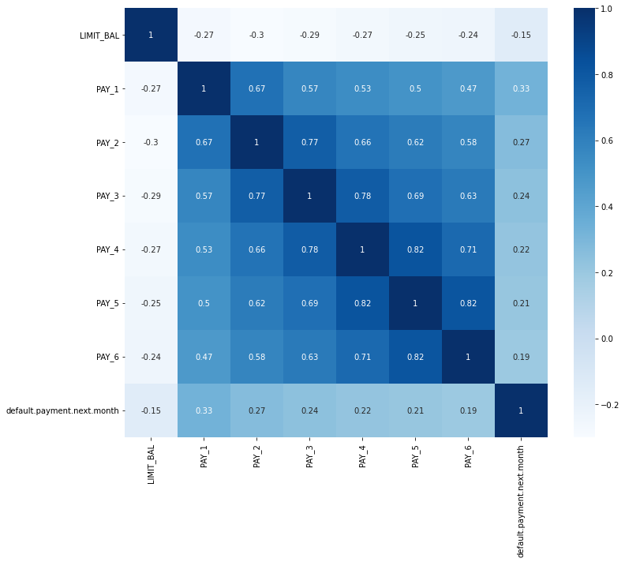

```python
import seaborn as sns

plt.figure(figsize=(12, 10))
sns.heatmap(cor_core, annot=True, cmap=plt.cm.Blues)
plt.show()
```

The correlation plot suggests the Repayment Status features are highly correlated. This makes sense because these features are lag features.

**Summary Statistics & Visualization 2: Distribution of LIMIT_BAL**

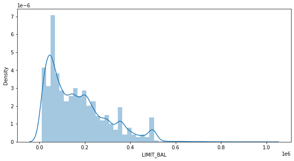

```python
plt.figure(figsize=(10, 5))
sns.distplot(train_df.LIMIT_BAL)
plt.show()
```

The distribution plot shows that the limit balance is right-skewed, and the majority of clients are given the credit line ranging from 0 to 200,000 (NT dollar).

**Metric Selection**

Lastly, we look at the distribution of the target variable.

```python
train_df["default.payment.next.month"].value_counts(normalize=True)
```

```
0    0.776762
1    0.223238
Name: default.payment.next.month, dtype: float64
```

We do have a class imbalance in the data set since only 22% of the examples in the training set belong to the "default" class (class 1). We are more interested in the "default" class because it is more important to catch as many credit card clients who will default as possible so that the bank can stop offering them credit lines. Therefore, we decided to pick the f1-score as our most important metric.

```python
scoring = ["accuracy", "recall", "precision", "f1", "average_precision"]
```

## 4. Preprocessing and transformations

In this part, we focus on:

1. Identify different feature types and the transformations we apply on each feature type.
2. Define a column transformer

```python
# 1. Identify feature types

drop_features = ["ID"]

categorical_features = ["MARRIAGE", "EDUCATION"]

binary_features = ["SEX"]

numeric_features = list(
    set(X_train.columns)
    - set(categorical_features)
    - set(binary_features)
    - set(drop_features)
)
```

**Rationality**

- drop_features: Drop ID as it is a unique identifier for each row that is unlikely to be useful.
- categorical_features: MARRIAGE and EDUCATION are numbers to begin with but have categorical meanings. Note: EDUCATION looks like an already encoded ordinal column. However, the undefined/unknown values are problematic, and the documentation does not provide enough information on how to deal with them properly. Hence, we would encode this feature with OHE.
- binary_features: SEX is binary.
- numeric_features: Treat the rest as numeric and standardize them. Note: PAY_1 - PAY_6 look like already encoded ordinal features. Moreover, even though these features are collinear, it should not be a problem because we are using regularized models. Hence, I would keep all these features and treat them as numeric to apply scaling on.

```python
# 2. Define a column transformer

numeric_transformer = make_pipeline(StandardScaler())

binary_transformer = make_pipeline(OneHotEncoder(drop="if_binary", dtype=int))

categorical_transformer = make_pipeline(OneHotEncoder(handle_unknown="ignore", sparse=False))

preprocessor = make_column_transformer(
    (numeric_transformer, numeric_features),
    (binary_transformer, binary_features),
    (categorical_transformer, categorical_features),
    ("drop", drop_features),
)
```

```python
# 3. Transform training set
preprocessor.fit(X_train)
```

```
ColumnTransformer(transformers=[('pipeline-1',
                                 Pipeline(steps=[('standardscaler',
                                                  StandardScaler())]),
                                 ['BILL_AMT1', 'PAY_AMT4', 'BILL_AMT5',
                                  'BILL_AMT2', 'PAY_AMT3', 'LIMIT_BAL', 'PAY_6',
                                  'PAY_AMT2', 'PAY_1', 'PAY_2', 'PAY_AMT6',
                                  'PAY_AMT5', 'PAY_4', 'BILL_AMT6', 'BILL_AMT4',
                                  'AGE', 'BILL_AMT3', 'PAY_3', 'PAY_5',
                                  'PAY_AMT1']),
                                ('pipeline-2',
                                 Pipeline(steps=[('onehotencoder',
                                                  OneHotEncoder(drop='if_binary',
                                                                dtype=<class 'int'>))]),
                                 ['SEX']),
                                ('pipeline-3',
                                 Pipeline(steps=[('onehotencoder',
                                                  OneHotEncoder(handle_unknown='ignore',
                                                                sparse=False))]),
                                 ['MARRIAGE', 'EDUCATION']),
                                ('drop', 'drop', ['ID'])])
```

## 5. Baseline model

In this part we will try baseline model as a starting benchmark.

We use `scikit-learn`'s baseline model and report results.

Since this is a classification problem, we will use DummyClassifier as the baseline model.

```python
results = {}
```

```python
# The code is adapted from lectures and previous labs:

def mean_std_cross_val_scores(model, X_train, y_train, **kwargs):
    """
    Returns mean and std of cross validation

    Parameters
    ----------
    model :
        scikit-learn model
    X_train : numpy array or pandas DataFrame
        X in the training data
    y_train :
        y in the training data

    Returns
    ----------
        pandas Series with mean scores from cross_validation
    """

    scores = cross_validate(model, X_train, y_train, **kwargs)

    mean_scores = pd.DataFrame(scores).mean()
    std_scores = pd.DataFrame(scores).std()
    out_col = []

    for i in range(len(mean_scores)):
        out_col.append((f"%0.3f (+/- %0.3f)" % (mean_scores[i], std_scores[i])))

    return pd.Series(data=out_col, index=mean_scores.index)
```

```python
dummy_model = DummyClassifier(strategy="stratified")
results["Dummy"] = mean_std_cross_val_scores(
    dummy_model, X_train, y_train, return_train_score=True, scoring=scoring
)
pd.DataFrame(results)
```

|  | Dummy |
| --- | --- |
| fit_time | 0.001 (+/- 0.000) |
| score_time | 0.004 (+/- 0.000) |
| test_accuracy | 0.650 (+/- 0.005) |
| train_accuracy | 0.655 (+/- 0.004) |
| test_recall | 0.227 (+/- 0.010) |
| train_recall | 0.225 (+/- 0.012) |
| test_precision | 0.223 (+/- 0.009) |
| train_precision | 0.226 (+/- 0.009) |
| test_f1 | 0.225 (+/- 0.009) |
| train_f1 | 0.225 (+/- 0.010) |
| test_average_precision | 0.224 (+/- 0.001) |
| train_average_precision | 0.223 (+/- 0.001) |

**Result** The test scores are very low. F1=0.225 only.

## 6. Linear models

Next, we want to try a linear model as a first real attempt. Also, we carry out hyperparameter tuning to explore different values for the regularization hyperparameter. After that, we report cross-validation scores along with standard deviation and summarize our results.

Since this is a classification problem,we will use LogisticRegression as our linear model.

Note: As seen above, we have a class imbalance in the data set. Hence, we apply `class_weight="balanced"` before hyperparameter optimization to deal with the class imbalance. Since doing so results in much better scores, we will fix this in hyperparamter optimization and search for other hyperparameters.

```python
# 1. Run logistic regression without hyperparameter optimization

pipe_lr = make_pipeline(
    preprocessor, LogisticRegression(max_iter=1000, class_weight="balanced", random_state=123)
)
results["Logistic Regression"] = mean_std_cross_val_scores(
    pipe_lr, X_train, y_train, return_train_score=True, scoring=scoring
)
pd.DataFrame(results)
```

|  | Dummy | Logistic Regression |
| --- | --- | --- |
| fit_time | 0.001 (+/- 0.000) | 0.324 (+/- 0.061) |
| score_time | 0.004 (+/- 0.000) | 0.013 (+/- 0.002) |
| test_accuracy | 0.650 (+/- 0.005) | 0.683 (+/- 0.007) |
| train_accuracy | 0.655 (+/- 0.004) | 0.686 (+/- 0.003) |
| test_recall | 0.227 (+/- 0.010) | 0.646 (+/- 0.021) |
| train_recall | 0.225 (+/- 0.012) | 0.649 (+/- 0.005) |
| test_precision | 0.223 (+/- 0.009) | 0.378 (+/- 0.007) |
| train_precision | 0.226 (+/- 0.009) | 0.381 (+/- 0.003) |
| test_f1 | 0.225 (+/- 0.009) | 0.477 (+/- 0.009) |
| train_f1 | 0.225 (+/- 0.010) | 0.480 (+/- 0.003) |
| test_average_precision | 0.224 (+/- 0.001) | 0.507 (+/- 0.016) |
| train_average_precision | 0.223 (+/- 0.001) | 0.509 (+/- 0.004) |

```python
# 2. Carry out hyperparameter optimization

from sklearn.model_selection import RandomizedSearchCV
from scipy.stats import loguniform

param_dist_lr = {
    "logisticregression__C": loguniform(1e-3, 1e3),
}

search_lr = RandomizedSearchCV(
    pipe_lr,
    param_dist_lr,
    n_iter=50,
    verbose=1,
    n_jobs=-1,
    return_train_score=True,
    scoring="f1",
    random_state=123,
)

search_lr.fit(X_train, y_train);
```

```
Fitting 5 folds for each of 50 candidates, totalling 250 fits
```

```python
search_lr.best_params_
```

```
{'logisticregression__C': 0.011290431413903904}
```

```python
search_lr.best_score_
```

```
0.47983419889173823
```

```python
# 3. Report scores

results["Tuned Logistic Regression"] = mean_std_cross_val_scores(
    search_lr.best_estimator_, X_train, y_train, return_train_score=True, scoring=scoring
)
pd.DataFrame(results)
```

|  | Dummy | Logistic Regression | Tuned Logistic Regression |
| --- | --- | --- | --- |
| fit_time | 0.001 (+/- 0.000) | 0.324 (+/- 0.061) | 0.068 (+/- 0.005) |
| score_time | 0.004 (+/- 0.000) | 0.013 (+/- 0.002) | 0.012 (+/- 0.002) |
| test_accuracy | 0.650 (+/- 0.005) | 0.683 (+/- 0.007) | 0.689 (+/- 0.007) |
| train_accuracy | 0.655 (+/- 0.004) | 0.686 (+/- 0.003) | 0.690 (+/- 0.003) |
| test_recall | 0.227 (+/- 0.010) | 0.646 (+/- 0.021) | 0.642 (+/- 0.021) |
| train_recall | 0.225 (+/- 0.012) | 0.649 (+/- 0.005) | 0.643 (+/- 0.004) |
| test_precision | 0.223 (+/- 0.009) | 0.378 (+/- 0.007) | 0.383 (+/- 0.008) |
| train_precision | 0.226 (+/- 0.009) | 0.381 (+/- 0.003) | 0.384 (+/- 0.004) |
| test_f1 | 0.225 (+/- 0.009) | 0.477 (+/- 0.009) | 0.480 (+/- 0.009) |
| train_f1 | 0.225 (+/- 0.010) | 0.480 (+/- 0.003) | 0.481 (+/- 0.004) |
| test_average_precision | 0.224 (+/- 0.001) | 0.507 (+/- 0.016) | 0.507 (+/- 0.015) |
| train_average_precision | 0.223 (+/- 0.001) | 0.509 (+/- 0.004) | 0.508 (+/- 0.004) |

**Summarize the results:**

- The best hyperparameter found by our random search is C = 0.01 with a validation f1-score of 0.48.
- The tuned logistic regression model seems to not improve much compared to the model without hyperparameter optimization. In fact, recall decreases a bit while accuracy, precision, and f1 slightly increase.

## 7. Different machine learning models

We will try at least 3 other models aside from a linear model then summarize the results in terms of overfitting/underfitting and fit and score times. From the results, it is interesting that we can figure out if machine learning model can beat a linear model.

**Machine Learning Models**

We decide to choose RandomForest, KNeighbors, and LGBM as 3 models for this classification purpose.

```python
from sklearn.ensemble import RandomForestClassifier
from sklearn.neighbors import KNeighborsClassifier
from lightgbm.sklearn import LGBMClassifier

pipe_rf = make_pipeline(preprocessor, RandomForestClassifier(class_weight="balanced", random_state=123))
pipe_knn = make_pipeline(preprocessor, KNeighborsClassifier())
pipe_lgbm = make_pipeline(preprocessor, LGBMClassifier(class_weight="balanced", random_state=123))

models = {
    "Random Forest": pipe_rf,
    "KNN": pipe_knn,
    "LightGBM": pipe_lgbm
}
```

```python
for (name, model) in models.items():
    results[name] = mean_std_cross_val_scores(
        model, X_train, y_train, return_train_score=True, scoring=scoring
    )
pd.DataFrame(results)
```

|  | Dummy | Logistic Regression | Tuned Logistic Regression | Random Forest | KNN | LightGBM |
| --- | --- | --- | --- | --- | --- | --- |
| fit_time | 0.001 (+/- 0.000) | 0.324 (+/- 0.061) | 0.068 (+/- 0.005) | 2.706 (+/- 0.034) | 0.017 (+/- 0.004) | 0.187 (+/- 0.013) |
| score_time | 0.004 (+/- 0.000) | 0.013 (+/- 0.002) | 0.012 (+/- 0.002) | 0.132 (+/- 0.003) | 2.457 (+/- 0.198) | 0.027 (+/- 0.001) |
| test_accuracy | 0.650 (+/- 0.005) | 0.683 (+/- 0.007) | 0.689 (+/- 0.007) | 0.814 (+/- 0.005) | 0.793 (+/- 0.005) | 0.765 (+/- 0.007) |
| train_accuracy | 0.655 (+/- 0.004) | 0.686 (+/- 0.003) | 0.690 (+/- 0.003) | 0.999 (+/- 0.000) | 0.844 (+/- 0.001) | 0.824 (+/- 0.003) |
| test_recall | 0.227 (+/- 0.010) | 0.646 (+/- 0.021) | 0.642 (+/- 0.021) | 0.348 (+/- 0.013) | 0.355 (+/- 0.012) | 0.615 (+/- 0.014) |
| train_recall | 0.225 (+/- 0.012) | 0.649 (+/- 0.005) | 0.643 (+/- 0.004) | 1.000 (+/- 0.000) | 0.471 (+/- 0.004) | 0.775 (+/- 0.009) |
| test_precision | 0.223 (+/- 0.009) | 0.378 (+/- 0.007) | 0.383 (+/- 0.008) | 0.659 (+/- 0.024) | 0.559 (+/- 0.017) | 0.480 (+/- 0.012) |
| train_precision | 0.226 (+/- 0.009) | 0.381 (+/- 0.003) | 0.384 (+/- 0.004) | 0.997 (+/- 0.000) | 0.733 (+/- 0.004) | 0.580 (+/- 0.005) |
| test_f1 | 0.225 (+/- 0.009) | 0.477 (+/- 0.009) | 0.480 (+/- 0.009) | 0.455 (+/- 0.015) | 0.434 (+/- 0.013) | 0.539 (+/- 0.013) |
| train_f1 | 0.225 (+/- 0.010) | 0.480 (+/- 0.003) | 0.481 (+/- 0.004) | 0.998 (+/- 0.000) | 0.573 (+/- 0.003) | 0.664 (+/- 0.004) |
| test_average_precision | 0.224 (+/- 0.001) | 0.507 (+/- 0.016) | 0.507 (+/- 0.015) | 0.541 (+/- 0.017) | 0.418 (+/- 0.009) | 0.562 (+/- 0.019) |
| train_average_precision | 0.223 (+/- 0.001) | 0.509 (+/- 0.004) | 0.508 (+/- 0.004) | 1.000 (+/- 0.000) | 0.643 (+/- 0.004) | 0.739 (+/- 0.003) |

**Summarize the results:**

- Regarding score, LightGBM has the highest validation f1 score while KNN has the lowest. Hence, we can see that not all non-linear model can beat the linear model.
- Regarding overfitting/ underfitting, Random Forest is overfitting badly because the F1 score on the train set is 0.998 while on test set is only 0.455.
- Regarding fit and score time, most models are quite quick, except Random Forest takes a while to fit and KNN takes a while to score.

*Overall, `LightGBM` is the best performing model as it achieves the best score, is fast, and does not overfit/underfit.*

## 8. Hyperparameter optimization

We perform hyperparameter optimization on the best-performing model, which is `LightGBM` and summarize the results. We use `sklearn`'s methods for hyperparameter optimization.

- [RandomizedSearchCV](http://scikit-learn.org/stable/modules/generated/sklearn.model_selection.RandomizedSearchCV.html)

```python
import numpy as np
param_dist_lgbm = {
    "lgbmclassifier__max_depth": np.arange(1, 20, 2),
    "lgbmclassifier__num_leaves": np.arange(20, 80, 5),
    "lgbmclassifier__max_bin": np.arange(200, 300, 20),
}

search_lgbm = RandomizedSearchCV(
    pipe_lgbm,
    param_dist_lgbm,
    n_iter=50,
    verbose=1,
    n_jobs=-1,
    return_train_score=True,
    scoring="f1",
    random_state=123,
)

search_lgbm.fit(X_train, y_train);
```

```
Fitting 5 folds for each of 50 candidates, totalling 250 fits
```

```python
results["Tuned LGBMClassification"] = mean_std_cross_val_scores(
    search_lgbm.best_estimator_, X_train, y_train, return_train_score=True, scoring=scoring
)
pd.DataFrame(results)
```

|  | Dummy | Logistic Regression | Tuned Logistic Regression | Random Forest | KNN | LightGBM | Tuned LGBMClassification |
| --- | --- | --- | --- | --- | --- | --- | --- |
| fit_time | 0.001 (+/- 0.000) | 0.324 (+/- 0.061) | 0.068 (+/- 0.005) | 2.706 (+/- 0.034) | 0.017 (+/- 0.004) | 0.187 (+/- 0.013) | 0.133 (+/- 0.003) |
| score_time | 0.004 (+/- 0.000) | 0.013 (+/- 0.002) | 0.012 (+/- 0.002) | 0.132 (+/- 0.003) | 2.457 (+/- 0.198) | 0.027 (+/- 0.001) | 0.022 (+/- 0.001) |
| test_accuracy | 0.650 (+/- 0.005) | 0.683 (+/- 0.007) | 0.689 (+/- 0.007) | 0.814 (+/- 0.005) | 0.793 (+/- 0.005) | 0.765 (+/- 0.007) | 0.768 (+/- 0.008) |
| train_accuracy | 0.655 (+/- 0.004) | 0.686 (+/- 0.003) | 0.690 (+/- 0.003) | 0.999 (+/- 0.000) | 0.844 (+/- 0.001) | 0.824 (+/- 0.003) | 0.801 (+/- 0.004) |
| test_recall | 0.227 (+/- 0.010) | 0.646 (+/- 0.021) | 0.642 (+/- 0.021) | 0.348 (+/- 0.013) | 0.355 (+/- 0.012) | 0.615 (+/- 0.014) | 0.625 (+/- 0.016) |
| train_recall | 0.225 (+/- 0.012) | 0.649 (+/- 0.005) | 0.643 (+/- 0.004) | 1.000 (+/- 0.000) | 0.471 (+/- 0.004) | 0.775 (+/- 0.009) | 0.698 (+/- 0.006) |
| test_precision | 0.223 (+/- 0.009) | 0.378 (+/- 0.007) | 0.383 (+/- 0.008) | 0.659 (+/- 0.024) | 0.559 (+/- 0.017) | 0.480 (+/- 0.012) | 0.485 (+/- 0.014) |
| train_precision | 0.226 (+/- 0.009) | 0.381 (+/- 0.003) | 0.384 (+/- 0.004) | 0.997 (+/- 0.000) | 0.733 (+/- 0.004) | 0.580 (+/- 0.005) | 0.543 (+/- 0.008) |
| test_f1 | 0.225 (+/- 0.009) | 0.477 (+/- 0.009) | 0.480 (+/- 0.009) | 0.455 (+/- 0.015) | 0.434 (+/- 0.013) | 0.539 (+/- 0.013) | 0.546 (+/- 0.014) |
| train_f1 | 0.225 (+/- 0.010) | 0.480 (+/- 0.003) | 0.481 (+/- 0.004) | 0.998 (+/- 0.000) | 0.573 (+/- 0.003) | 0.664 (+/- 0.004) | 0.611 (+/- 0.005) |
| test_average_precision | 0.224 (+/- 0.001) | 0.507 (+/- 0.016) | 0.507 (+/- 0.015) | 0.541 (+/- 0.017) | 0.418 (+/- 0.009) | 0.562 (+/- 0.019) | 0.567 (+/- 0.019) |
| train_average_precision | 0.223 (+/- 0.001) | 0.509 (+/- 0.004) | 0.508 (+/- 0.004) | 1.000 (+/- 0.000) | 0.643 (+/- 0.004) | 0.739 (+/- 0.003) | 0.677 (+/- 0.005) |

```python
search_lgbm.best_params_
```

```
{'lgbmclassifier__num_leaves': 60,
 'lgbmclassifier__max_depth': 5,
 'lgbmclassifier__max_bin': 240}
```

```python
search_lgbm.best_score_
```

```
0.5459147030871935
```

## 9. Interpretation and feature importances

We use the `shap` methods to examine the most important features of the `LightGBM` models.

1. Summarize your observations.

```python
import shap
```

```python
preprocessor.fit(X_train, y_train)
ohe_feature_names = (
    preprocessor
    .named_transformers_["pipeline-3"]
    .named_steps["onehotencoder"]
    .get_feature_names_out(categorical_features)
    .tolist()
)
feature_names = numeric_features + binary_features + ohe_feature_names
```

```python
X_train_enc = pd.DataFrame(
    data=preprocessor.transform(X_train),
    columns=feature_names,
    index=X_train.index,
)
X_train_enc.head()
```

|  | BILL_AMT1 | PAY_AMT4 | BILL_AMT5 | BILL_AMT2 | PAY_AMT3 | LIMIT_BAL | PAY_6 | PAY_AMT2 | PAY_1 | PAY_2 | ... | MARRIAGE_1 | MARRIAGE_2 | MARRIAGE_3 | EDUCATION_0 | EDUCATION_1 | EDUCATION_2 | EDUCATION_3 | EDUCATION_4 | EDUCATION_5 | EDUCATION_6 |
| --- | --- | --- | --- | --- | --- | --- | --- | --- | --- | --- | --- | --- | --- | --- | --- | --- | --- | --- | --- | --- | --- |
| 16395 | -0.300665 | -0.114944 | -0.494781 | -0.293394 | -0.234603 | 1.168355 | 0.257059 | -0.040229 | 0.013770 | 0.114774 | ... | 0.0 | 1.0 | 0.0 | 0.0 | 1.0 | 0.0 | 0.0 | 0.0 | 0.0 | 0.0 |
| 21448 | -0.685307 | -0.113778 | 1.805461 | -0.679495 | 6.785208 | 2.090017 | 0.257059 | 3.739796 | -0.878738 | -0.722412 | ... | 0.0 | 1.0 | 0.0 | 0.0 | 1.0 | 0.0 | 0.0 | 0.0 | 0.0 | 0.0 |
| 20034 | -0.696132 | -0.309323 | -0.661045 | -0.688319 | -0.289017 | -0.060527 | -1.485154 | -0.270403 | -1.771246 | -1.559598 | ... | 1.0 | 0.0 | 0.0 | 0.0 | 0.0 | 0.0 | 1.0 | 0.0 | 0.0 | 0.0 |
| 25755 | 0.687456 | -0.113843 | 0.501203 | 0.752583 | -0.060260 | -0.367748 | 0.257059 | -0.018028 | 0.013770 | 0.114774 | ... | 1.0 | 0.0 | 0.0 | 0.0 | 0.0 | 1.0 | 0.0 | 0.0 | 0.0 | 0.0 |
| 1438 | -0.040230 | -0.212134 | -0.204599 | -0.031399 | -0.223720 | -0.905384 | 0.257059 | -0.206185 | 0.906278 | 1.789147 | ... | 0.0 | 1.0 | 0.0 | 0.0 | 0.0 | 1.0 | 0.0 | 0.0 | 0.0 | 0.0 |

5 rows × 32 columns

```python
X_test_enc = pd.DataFrame(
    data=preprocessor.transform(X_test),
    columns=feature_names,
    index=X_test.index,
)
X_test_enc.head()
```

|  | BILL_AMT1 | PAY_AMT4 | BILL_AMT5 | BILL_AMT2 | PAY_AMT3 | LIMIT_BAL | PAY_6 | PAY_AMT2 | PAY_1 | PAY_2 | ... | MARRIAGE_1 | MARRIAGE_2 | MARRIAGE_3 | EDUCATION_0 | EDUCATION_1 | EDUCATION_2 | EDUCATION_3 | EDUCATION_4 | EDUCATION_5 | EDUCATION_6 |
| --- | --- | --- | --- | --- | --- | --- | --- | --- | --- | --- | --- | --- | --- | --- | --- | --- | --- | --- | --- | --- | --- |
| 25665 | -0.301142 | 1.140290 | 0.058763 | -0.346448 | -0.289017 | -0.982189 | 0.257059 | -0.224533 | -0.878738 | 0.114774 | ... | 0.0 | 1.0 | 0.0 | 0.0 | 0.0 | 1.0 | 0.0 | 0.0 | 0.0 | 0.0 |
| 16464 | 0.334336 | -0.205460 | 0.162513 | 0.293371 | -0.180189 | -0.674969 | 0.257059 | -0.173801 | 0.013770 | 0.114774 | ... | 1.0 | 0.0 | 0.0 | 0.0 | 0.0 | 0.0 | 1.0 | 0.0 | 0.0 | 0.0 |
| 22386 | 1.427002 | 0.532986 | 2.086523 | 1.536341 | -0.289017 | 0.016278 | 1.999273 | 0.027750 | 1.798787 | 1.789147 | ... | 0.0 | 1.0 | 0.0 | 0.0 | 1.0 | 0.0 | 0.0 | 0.0 | 0.0 | 0.0 |
| 10149 | -0.374955 | -0.309323 | -0.660751 | -0.677772 | -0.289017 | 0.246693 | -1.485154 | -0.270403 | -1.771246 | -1.559598 | ... | 1.0 | 0.0 | 0.0 | 0.0 | 0.0 | 1.0 | 0.0 | 0.0 | 0.0 | 0.0 |
| 8729 | -0.584044 | -0.287229 | -0.506842 | -0.575543 | -0.271006 | -0.905384 | 0.257059 | -0.217653 | 0.013770 | 0.114774 | ... | 1.0 | 0.0 | 0.0 | 0.0 | 0.0 | 1.0 | 0.0 | 0.0 | 0.0 | 0.0 |

5 rows × 32 columns

```python
pipe_lgbm.fit(X_train, y_train);
```

```python
lgbm_explainer = shap.TreeExplainer(pipe_lgbm.named_steps["lgbmclassifier"])
train_lgbm_shap_values = lgbm_explainer.shap_values(X_train_enc)
```

```
LightGBM binary classifier with TreeExplainer shap values output has changed to a list of ndarray
```

```python
# We are only extracting shapely values for the first 100 test examples for speed.
test_lgbm_shap_values = lgbm_explainer.shap_values(X_test_enc[:100])
```

```python
shap.initjs()
```

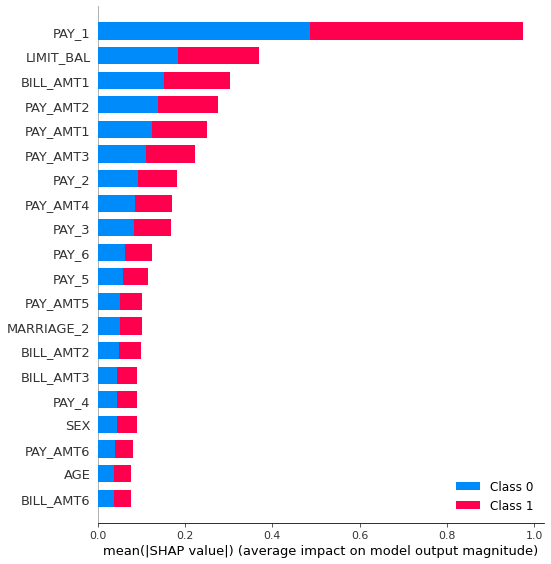

```python
shap.summary_plot(train_lgbm_shap_values, X_train_enc)
```

**Summary of Observations:**

- The plot shows global feature importances, where the features are ranked in descending order of feature importances.
- Colour shows the class of feature (red for default payment and blue for non-default payment)
- `PAY_1` is likely the most important feature while `BILL_AMT6` is likely the least important one.

## 10. Results on the test set

We try your best performing model `LightGBM` on the test data and report test scores to answer following questions:

1. Do the test scores agree with the validation scores from before?
2. To what extent do we trust our results?
3. Is there any optimization bias? After that we take one or two test predictions and explain them with SHAP force plots.

**Step 1**

1. Try on test data and report test scores.

```python
best_lgbm = search_lgbm.best_estimator_
```

```python
best_lgbm.predict(X_test)
```

```
array([0, 0, 1, ..., 1, 1, 1])
```

```python
f1_score(y_test,best_lgbm.predict(X_test))
```

```
0.5299528831052278
```

**Answer questions** The test score agrees with the validation score from `Section 8`. I would trust the result because the test score of 0.53 is just slightly lower than validation score of 0.546. Therefore, I think there's no issue with optimization bias in this case.

**Step 2**

1. Test predictions and explain with SHAP force plots.

```python
X_train_enc = X_train_enc.round(3)
X_test_enc = X_test_enc.round(3)
```

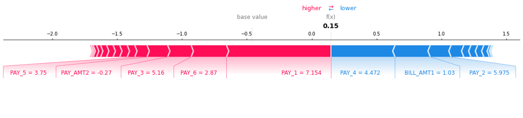

```python
shap.force_plot(
    lgbm_explainer.expected_value[1],
    test_lgbm_shap_values[1][31,:],
    X_test_enc.iloc[31, :],
    matplotlib=True,
)
```

- The raw model score is higher than the base value so the prediction is default (1) because this example was pushed higher by all the factors shown in red such as `PAY_1`, `PAY_6`.
- Meanwhile, `PAY_4`, `BILL_AMT1` are pushing the prediction towards lower score.

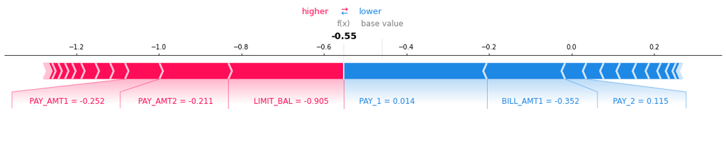

```python
shap.force_plot(
    lgbm_explainer.expected_value[1],
    test_lgbm_shap_values[1][6,:],
    X_test_enc.iloc[6, :],
    matplotlib=True,
)
```

- The raw model score is lower than the base value so the prediction is non-default (0) because this example was pushed lower by all the factors shown in blue such as `PAY_1`, `BILL_AMT1`.
- Meanwhile, `LIMIT_BAL`, `PAY_AMT2` are pushing the prediction towards higher score.

## 11. Summary of results

Here is the summary of these results to our readers.

**Summary Table**

```python
models = {
    "Dummy": dummy_model,
    "Logistic Regression": pipe_lr,
    "Tuned Logistic Regression": search_lr.best_estimator_,
    "Random Forest": pipe_rf,
    "KNN": pipe_knn,
    "LGBM": pipe_lgbm,
    "Best LightGBM": best_lgbm
}
```

```python
important_scores = ["f1"]
final_result={}
for (name, model) in models.items():
    final_result[name] = mean_std_cross_val_scores(
        model, X_train, y_train,
        return_train_score=True,
        scoring=important_scores
    )

pd.DataFrame(final_result)
```

|  | Dummy | Logistic Regression | Tuned Logistic Regression | Random Forest | KNN | LGBM | Best LightGBM |
| --- | --- | --- | --- | --- | --- | --- | --- |
| fit_time | 0.003 (+/- 0.001) | 0.269 (+/- 0.021) | 0.065 (+/- 0.004) | 2.665 (+/- 0.024) | 0.016 (+/- 0.003) | 0.230 (+/- 0.054) | 0.167 (+/- 0.076) |
| score_time | 0.002 (+/- 0.001) | 0.005 (+/- 0.000) | 0.005 (+/- 0.000) | 0.064 (+/- 0.001) | 1.248 (+/- 0.121) | 0.012 (+/- 0.001) | 0.010 (+/- 0.001) |
| test_f1 | 0.221 (+/- 0.016) | 0.477 (+/- 0.009) | 0.480 (+/- 0.009) | 0.455 (+/- 0.015) | 0.434 (+/- 0.013) | 0.539 (+/- 0.013) | 0.546 (+/- 0.014) |
| train_f1 | 0.225 (+/- 0.005) | 0.480 (+/- 0.003) | 0.481 (+/- 0.004) | 0.998 (+/- 0.000) | 0.573 (+/- 0.003) | 0.664 (+/- 0.004) | 0.611 (+/- 0.005) |

**Concluding remarks:**

- Best and worst performing models:

  > Random Forest model is much slower compared to other models. KNN performs worst but it fits much faster than other models.
- Score time

  > Scoring is fast for almost all models except KNN.
- Stability of scores

  > The scores look more or less stable with std in the range 0.009 to 0.016 for f1 score.

**Further development**

Due to time limit, there are shortcomings in our mini project; hence the f1 score of the best model is not quite satisfactory. If we are able to try different models (such as SVC, SVM, tree models) and implement feature engineering such as polinomial, it is possible that we can improve the performance/interpretability of this project.

**Result**

TEST SCORE: 0.53, METRIC: F1

**Takeaway**

The biggest takeaway of our group from this project is:

- To define and use evaluation metrics for classification and regression,
- To learn the importance of feature engineering in building machine learning models.
- To learn the importance of interpretability in Machine Learning.